# Blueprint simulator - Personal Edition

## Description

A script that simulates how long it takes to gather all remaining blueprints based on your personal inventory (saved in separate Excel sheet). Which takes into account the individual probabilities of the remaining blueprints. This script uses either a spender or hoarder strategy.

The spender strategy buys a new blueprint along the way while recycling any excess blueprints. The hoarder strategy instead saves all filaments from recycled blueprints and waits until has enough to buy all remaining missing blueprints (called here the *filament tipping point*).

If you want to change or update the underlying probabilities for each tier (perhaps based on your own measurements) then you can update them in the Excel file under the Data sheet.

By default the simulation works based on previously observed probabilities which are:

- Common: 0.6
- Decent: 0.25
- Nifty: 0.1
- Splendid: 0.05

## Personal

Found a total of 169 out of 528 already claimed blueprints. Remaining number of blueprints is 359. Additionally, a total of 10300 filament has been collected and will be used in the simulations.

Found a total of blueprints for each tier:

- Common: 99
- Decent: 43
- Nifty: 16
- Splendid: 11

## Simulation conditions

The number of blueprints claimable per week is 6.

The average time in hours it take for claiming all blueprints in a week is estimated to be around 9 hour and 30 minutes. [[1]](https://www.reddit.com/r/Oxygennotincluded/comments/1h8or9f/insights_on_the_new_blueprint_mechanics/)

The recycled yield is calculated as getting 50% back when recycled.

## Results

Ran using 1000 simulations per approach.

### Spender strategy

Average hours required: 1621

Average weeks required: 171

Average years required: 3.3

Average number of recycled blueprints: 816

### Hoarder strategy

Average hours required: 1472

Average weeks required: 155

Average years required: 3

Average number of recycled blueprints: 675

Average filament required for tipping point: 345K

## Visualizing distributions

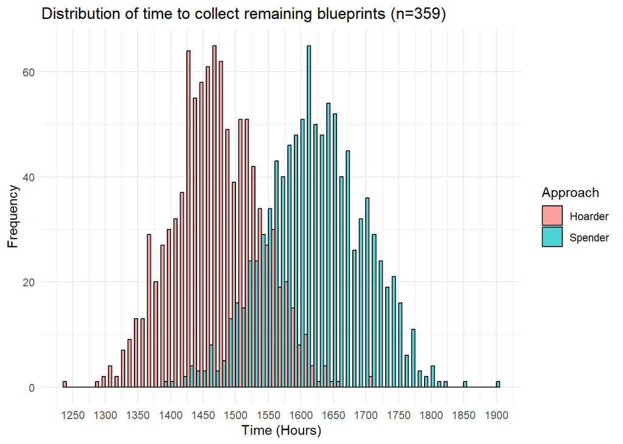

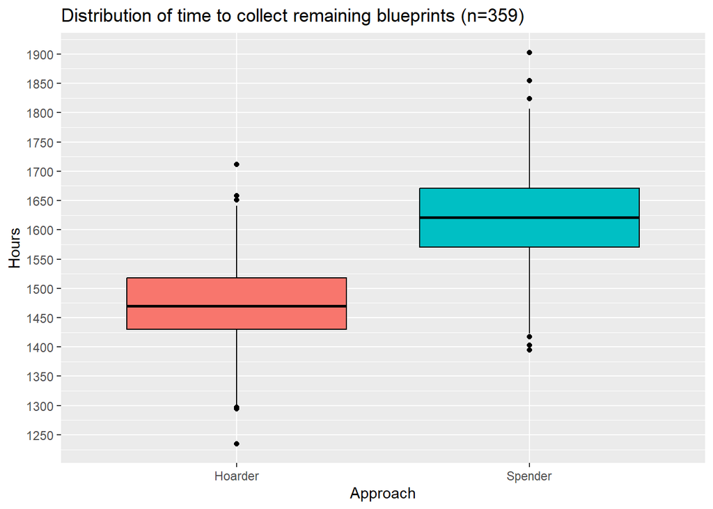

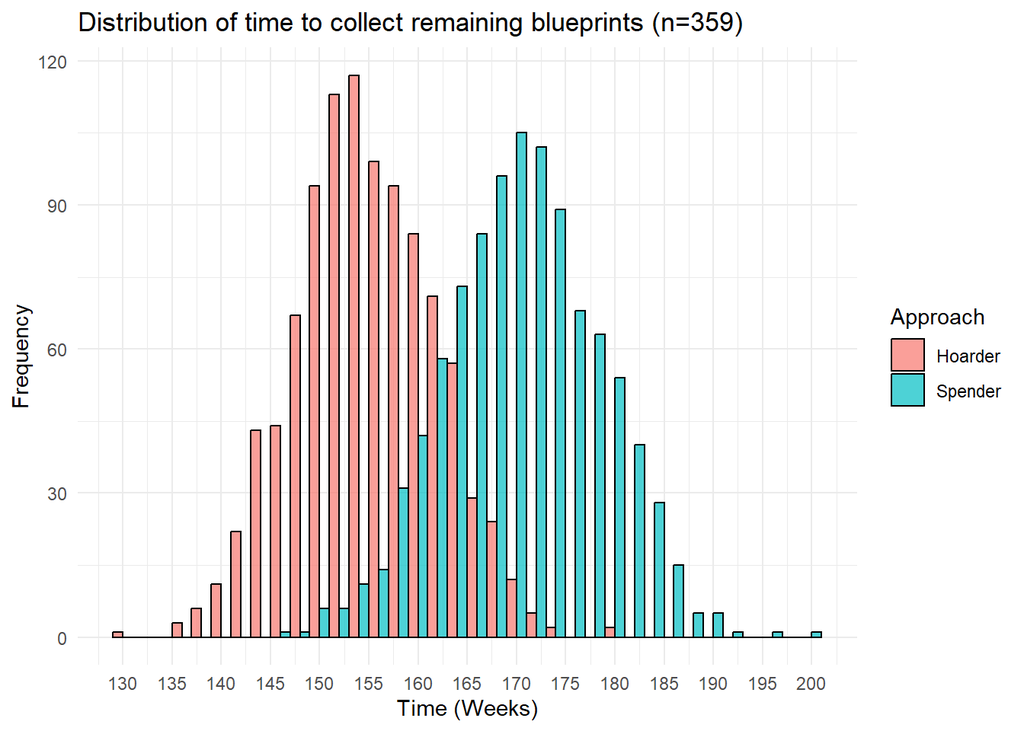

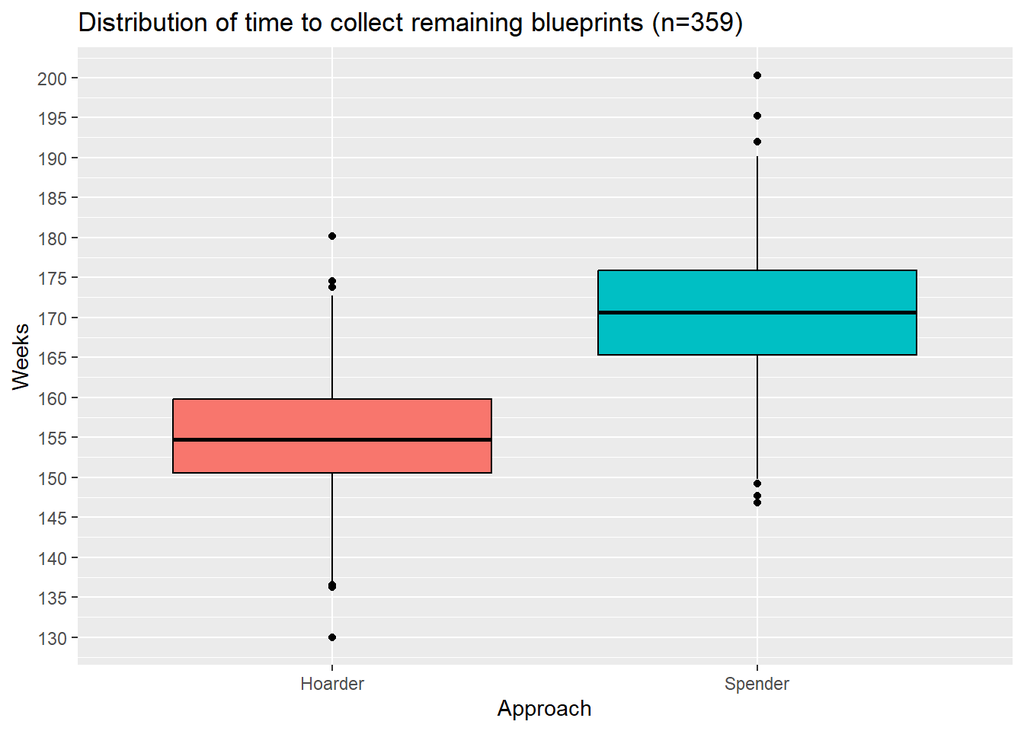

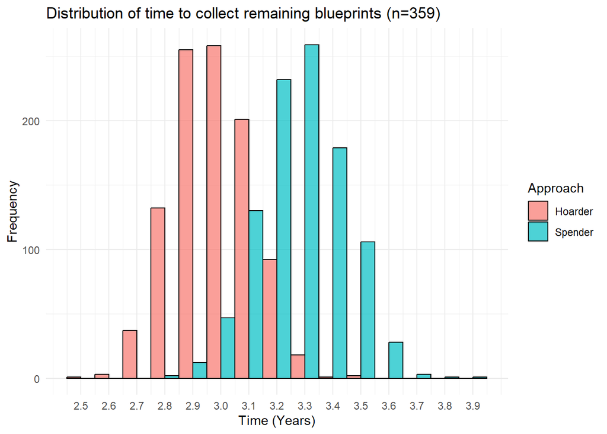

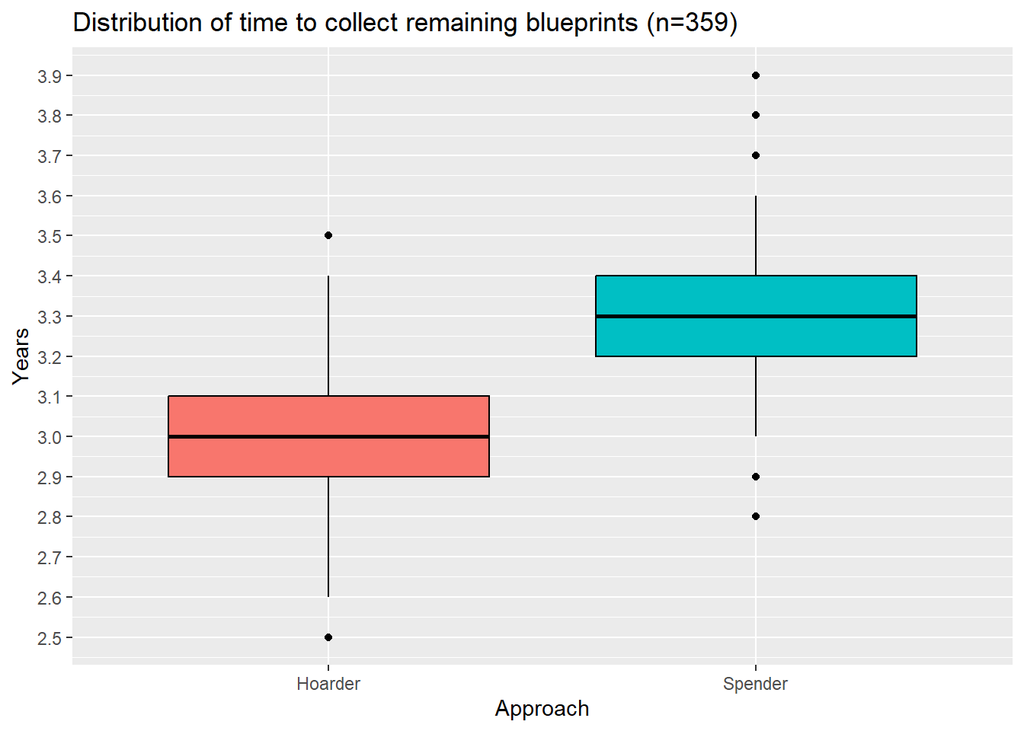

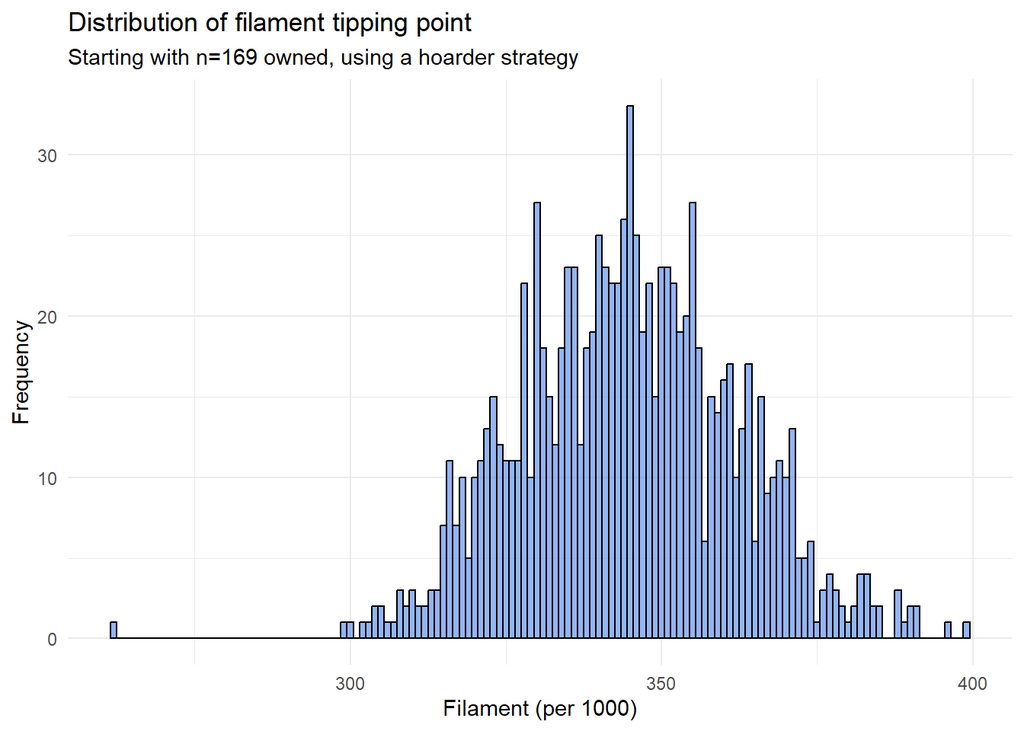

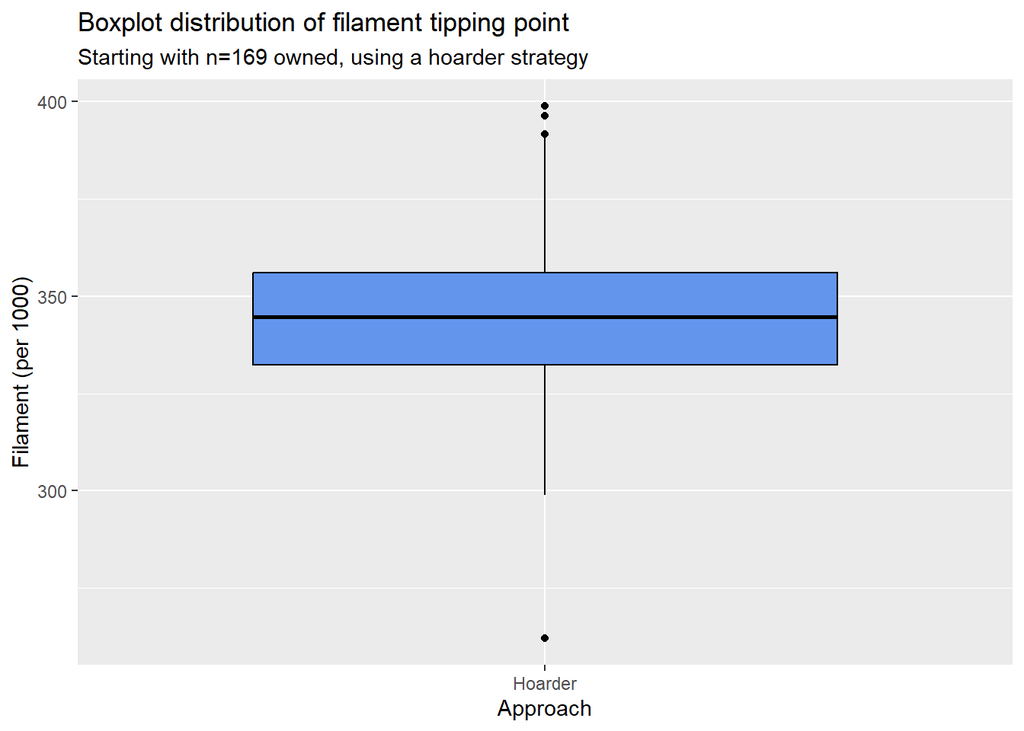